# Stalks evolution

## flower calendar

### Metadata information

Here is a table including the flower evolution in the time, like a type of flower calendar.

The day_birth means the day when the floral envelope opens. I have considered the birth day as the day when a petal take off of the others.

The day_death means the day when the floral envelope closes. I have considered the death day as the day when a folded petal cut the central axis of symmetry.

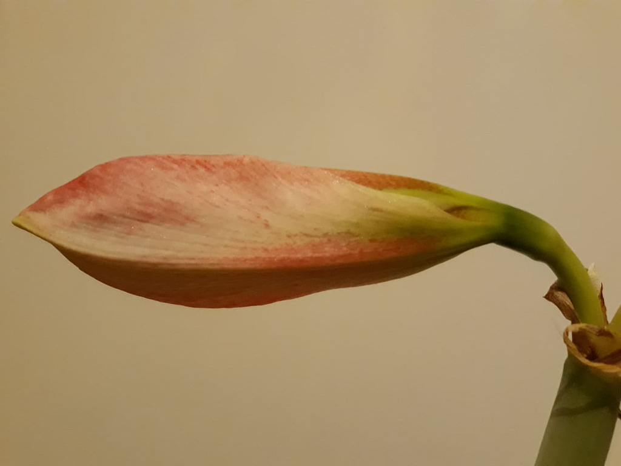

an unopened flower

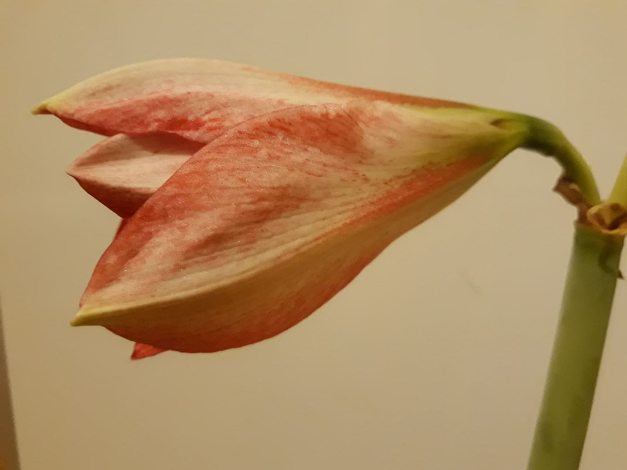

an opened flower

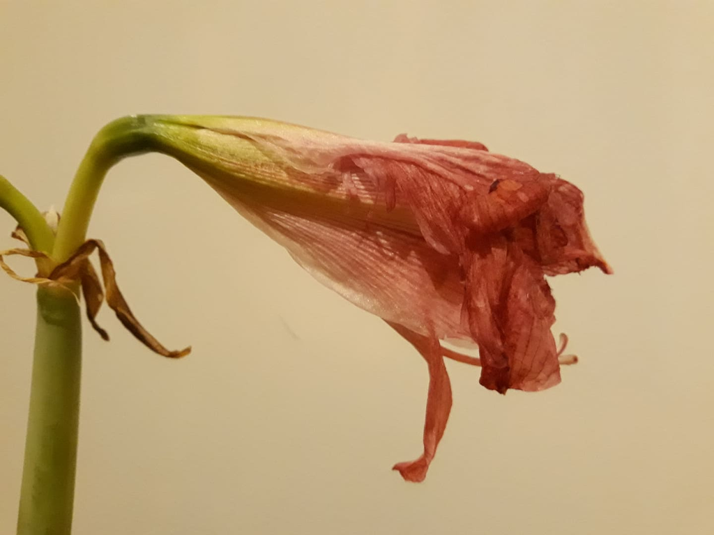

### Table

| stalk | number | day_birth | day_death |
| --- | --- | --- | --- |
| 1 | 1 | 4 | 10 |
| 1 | 2 | 12 | 18 |
| 2 | 1 | 0 | 0 |
| 2 | 2 | 0 | 0 |
| 3 | 1 | 0 | 0 |
| 3 | 2 | 0 | 0 |
| 4 | 1 | 0 | 0 |
| 4 | 2 | 0 | 0 |
| 5 | 1 | 0 | 0 |
| 5 | 2 | 0 | 0 |